# Act Report

WeRateDogs is a popular Twitter account that rates people's dogs with a humorous comment about the dog. These ratings almost always have a denominator of 10. They have been around since 2015 and have gained a huge following.

The data for this project was gathered from various sources, including the WeRateDogs Twitter account, the Udacity servers, and the Twitter API. The data consisted of three main tables, the df_twitter_archive, df_image_prediction, and twitter_json.

The data wrangling process was an essential step in preparing the WeRateDogs dataset for analysis. We were able to identify and fix various issues related to data quality and tidiness, and as a result, we were able to produce a cleaned and consolidated dataset that was ready for analysis.

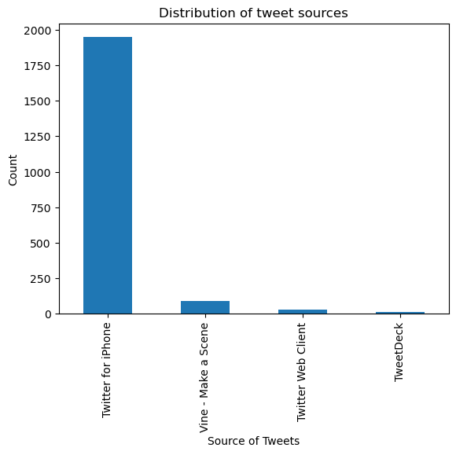

The second insight that we found is that the most popular dog names in the dataset are Charlie, Lucy, and Cooper. This is interesting because it shows that these are the most common dog names among the WeRateDogs community and people looking to name their dogs can choose one of the popular ones

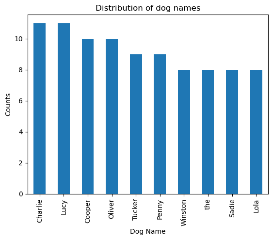

We also found that the most common dog stage in the dataset is pupper, followed by doggo and puppo. This insight can help new dog breeders understand the stages of dogs.

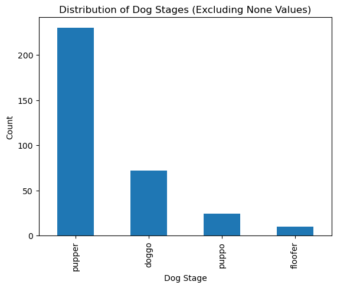

We also found that the top 3 predicted dog breeds in the first prediction column of df_image_prediction table were Golden Retriever, Labrador Retriever, and Pembroke. This is interesting because it shows that these are the most common dog breeds among the WeRateDogs community.

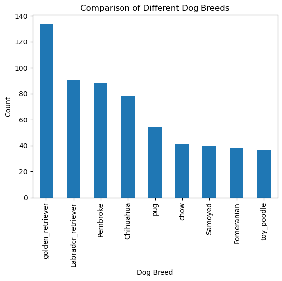

In conclusion, the WeRateDogs dataset provided a wealth of information that can be used to find out the dog stages, the popular names of dogs, the most popular dogs in the dog community and the phones the dog community love the most.